# Answers for the R Practice Assignments

Joy-El Talbot

6/9/2021

Updated 07/07/2021 by Joy-El Talbot

## Purpose

Provide a solution to the Weekly R Practice Assignments. These will provide a common starting point in each following week if folks need to get caught up or want to see one possible solution.

*Note: this example focuses on the R script aspect of the R Practice. While I’ll provide some commentary on the results, please do not take this document as an example of the ideal way to present a client-facing report. My goal here is to give you the CODE to keep moving forward.*

### Table of Contents

1. Purpose
2. Project Setup
3. Week 1
4. Week 2
5. Week 3
6. Week 4
7. Week 5
8. Week 6

## Project Setup

### Directory Setup

```r
# TODO set eval=TRUE in line above to RUN this code
# Leave as is, if you already have this directory structure and are running this file from within the analysis/ folder.
dir.create("data/")
dir.create("src/")
dir.create("analysis/")
dir.create("results/")
```

### Load Libaries

```r
library(ggplot2)
library(tidyr)
library(dplyr)
library(scales) # for comma separator in labels
library(PerformanceAnalytics) # for alternative correlation plot
```

### Define Constants

```r
# input source
DATADIR <- "data/"

# build results directory
# TODO name your analysis with the ANALYSISNAME constant
ANALYSISNAME <- "R_Practice_Answers"  # NO spaces!

DATESTAMP <- format(Sys.time(), "%Y-%m-%d")
RESULTSDIR <- paste0("results/",DATESTAMP,"-",ANALYSISNAME,"-results/")
dir.create(RESULTSDIR)
```

```r
GRAPHDIR <- paste0(RESULTSDIR, "graphs/")
dir.create(GRAPHDIR)
TABLEDIR <- paste0(RESULTSDIR, "tables/")
dir.create(TABLEDIR)
# define default plot size
PLOT_WIDTH <- 5
PLOT_HEIGHT <- 5
PLOT_UNITS <- "in"
PLOT_RES <- 96 # required for png() device when units aren't "px"
```

## Week 1

### Assignment (summarized)

1. Create an R script (this document) and Word Report (not shown/provided)
2. Import the sampled_dailyCheckouts.csv file, which contains 183,492 rows and 9 columns.
3. Data cleanup - with particular focus on week of year, day of week, date, unified age, and ID formatting.
4. Create and export frequency tables, cross-tabulations, histograms, etc. ANSWER: How do you show and compare the results across multiple classes?

### Step 2 - Load Data

```r
checkouts <- read.csv(paste0(DATADIR,"sampled_dailyCheckouts.csv"),
                      stringsAsFactors = FALSE)

# confirm its dimensions match expected 183,492 rows x 9 columns
dim(checkouts)
```

```
## [1] 183492      9
```

### Step 3: Data Cleanup

#### Step 3a: Initial inspection

Let’s look at the data a little to identify what cleanup might be needed. This will get the first pass of the data cleaning, but it is likely that we will find more cleanup needs as we continue analysis.

```r
head(checkouts)
```

```
##                            ID CheckoutYear       CheckoutDateTime
## 1 201905301410000020880608886         2019 05/30/2019 02:10:00 PM
## 2 201812231400000004064642480         2018 12/23/2018 02:00:00 PM
## 3 201910021657000024122242622         2019 10/02/2019 04:57:00 PM
## 4 201910111707000002522848088         2019 10/11/2019 05:07:00 PM
## 5 201811031017000009066466860         2018 11/03/2018 10:17:00 AM
## 6 201809091338000025786224062         2018 09/09/2018 01:38:00 PM
##   isInterlibraryLoan isLargePrint Age.Group.item Age.Group.collection
## 1              FALSE        FALSE          Adult                Adult
## 2              FALSE        FALSE          Adult                Adult
## 3              FALSE        FALSE          Adult                Adult
## 4              FALSE        FALSE          Adult                Adult
## 5              FALSE        FALSE          Adult                Adult
## 6              FALSE        FALSE          Adult                Adult
##   Category.Group.collection Category.Subgroup.collection
## 1                Nonfiction                    Biography
## 2                Nonfiction                    Biography
## 3                Nonfiction                    Biography
## 4                Nonfiction                    Biography
## 5                Nonfiction                    Biography
## 6                Nonfiction                    Biography
```

```r
# years covered
unique(checkouts$CheckoutYear)
```

```
## [1] 2019 2018 2020
```

```r
# age review - let's group by to see if there are any oddities between the two columns
checkouts %>%
  group_by(Age.Group.item, Age.Group.collection) %>%
  summarize(count = n())
```

```
## # A tibble: 6 x 3
## # Groups:   Age.Group.item [2]
##   Age.Group.item Age.Group.collection count
##   <chr>          <chr>                <int>
## 1 Adult          Adult                90564
## 2 Adult          Juvenile                57
## 3 Adult          Teen                  8318
## 4 Juvenile       Adult                  255
## 5 Juvenile       Juvenile             84258
## 6 Juvenile       Teen                    40
```

```r
# Types of categories/subcategories
# subgroups code modified from Psidom's response: https://stackoverflow.com/questions/51090048/concatenate-unique-strings-after-groupby-in-r
checkouts %>%
  group_by(Category.Group.collection) %>%
  summarize(count = n(),
            subgroups = paste(unique(Category.Subgroup.collection), collapse = ','))
```

```
## # A tibble: 7 x 3
##   Category.Group.collection  count subgroups
##   <chr>                      <int> <chr>
## 1 ""                             7 ""
## 2 "Fiction"                 114606 "Comic,,Large Print,Holiday,Picture,Peak Pic~
## 3 "Language"                  2715 ""
## 4 "Miscellaneous"             1195 ""
## 5 "Nonfiction"               64335 "Biography,,Large Print,Peak Picks"
## 6 "On Order"                    12 ""
## 7 "Reference"                  622 ",Biography"
```

#### Step 3b: Cleanup Focuses

Based on our initial inspection of the data.

1. Timestamp - Apparent regular format of MM/DD/YYYY HH:MM:SS AM/PM. *Will break into a date column (as POSIXlt object) AND Hour of day (as 24hr format); also extract week of year and day of week values per notes*
2. Age group - Some mismatches & additional category “Teen” in the Age.Group.collection - represent 8.5% of Adult books and 0.3% of Juvenile books (per Age.Group.item). *Will use the Age.Group.item for age categories moving forward.*
3. Category.Groups - Mostly Fiction & Non-Fiction; note that there are some unclassified subgroups (empty string). *Will reduce data to just Fiction & Non-Fiction AND add “General” as the subgroup where it is currently blank.*

```r
# 1. Convert CheckoutDateTime (currently <chr> type; aka string/character) to timestamp
checkouts$DateTime <- strptime(checkouts$CheckoutDateTime,
                               format = "%m/%d/%Y %I:%M:%S %p")
#head(checkouts) # running in Rmd shows <S3: POSIXlt> format; running directly in command line shows this: 2019-05-30 14:10:00

# Now, let's use this all-encompasing date object to get out subsets for our convenience
checkouts$Date <- strftime(checkouts$DateTime, format = "%Y-%m-%d")
# convert to a date object
checkouts$Date <- as.Date(checkouts$Date)

checkouts$Month <- strftime(checkouts$DateTime, format = "%B") # Month name
# turn CheckoutMonth into an ordered factor to ease plotting later
checkouts$Month <- factor(checkouts$Month,
                                  levels = c("January", "February", "March",
                                             "April", "May", "June",
                                             "July", "August", "September",
                                             "October", "November", "December"),
                                  ordered = TRUE) # keeps the order we used in the list provided for levels

checkouts$Hour <- strftime(checkouts$DateTime, format = "%H") # in 24-hr style
# checkout HOUR is going to always round DOWN (because we are just stripping the hour from the time), but that's ok

checkouts$WeekOfYear <- strftime(checkouts$DateTime, format = "%V") # ISO8601 week of year

checkouts$DayOfWeek <- strftime(checkouts$DateTime, format = "%A") # Full weekday name
# Factor this value as well
checkouts$DayOfWeek <- factor(checkouts$DayOfWeek,
                                      levels = c("Monday", "Tuesday", "Wednesday",
                                                 "Thursday", "Friday",
                                                 "Saturday", "Sunday"),
                                      ordered = TRUE)

# let's take a peak
checkouts %>%
  select(CheckoutDateTime, DateTime,
         Date, Month, Hour, WeekOfYear, DayOfWeek) %>%
  head()
```

```
##         CheckoutDateTime            DateTime       Date     Month Hour
## 1 05/30/2019 02:10:00 PM 2019-05-30 14:10:00 2019-05-30       May   14
## 2 12/23/2018 02:00:00 PM 2018-12-23 14:00:00 2018-12-23  December   14
## 3 10/02/2019 04:57:00 PM 2019-10-02 16:57:00 2019-10-02   October   16
## 4 10/11/2019 05:07:00 PM 2019-10-11 17:07:00 2019-10-11   October   17
## 5 11/03/2018 10:17:00 AM 2018-11-03 10:17:00 2018-11-03  November   10
## 6 09/09/2018 01:38:00 PM 2018-09-09 13:38:00 2018-09-09 September   13
##   WeekOfYear DayOfWeek
## 1         22  Thursday
## 2         51    Sunday
## 3         40 Wednesday
## 4         41    Friday
## 5         44  Saturday
## 6         36    Sunday
```

```r
# just dropping the extra age group
# There are many ways to do this, here is one:
checkouts <- subset(checkouts, select = -Age.Group.collection)
names(checkouts) # confirm intended Age.Group.collection is no longer there
```

```
##  [1] "ID"                           "CheckoutYear"
##  [3] "CheckoutDateTime"             "isInterlibraryLoan"
##  [5] "isLargePrint"                 "Age.Group.item"
##  [7] "Category.Group.collection"    "Category.Subgroup.collection"
##  [9] "DateTime"                     "Date"
## [11] "Month"                        "Hour"
## [13] "WeekOfYear"                   "DayOfWeek"
```

```r
# change blanks to "General" for subgroup

# before there are ___ blanks:
sum(checkouts$Category.Subgroup.collection == "") # sum because TRUE = 1 and FALSE = 0
```

```
## [1] 116621
```

```r
# taking a slice of the Category.Subgroup.collection to include all blank (empty string) values
# and overwriting those to "General"
checkouts$Category.Subgroup.collection[checkouts$Category.Subgroup.collection == ""] <- "General"
sum(checkouts$Category.Subgroup.collection == "") # expect 0
```

```
## [1] 0
```

```r
sum(checkouts$Category.Subgroup.collection == "General") # expect 116,621
```

```
## [1] 116621
```

```r
# Drop rows that aren't fiction/nonfiction
checkouts <- checkouts %>%
  filter(Category.Group.collection %in% c("Nonfiction", "Fiction"))

# Preview results
checkouts %>%
  group_by(Category.Group.collection, Category.Subgroup.collection) %>%
  summarize(count = n())
```

```
## # A tibble: 10 x 3
## # Groups:   Category.Group.collection [2]
##    Category.Group.collection Category.Subgroup.collection count
##    <chr>                     <chr>                        <int>
##  1 Fiction                   Comic                        16082
##  2 Fiction                   General                      54942
##  3 Fiction                   Holiday                       1898
##  4 Fiction                   Large Print                   2115
##  5 Fiction                   Peak Picks                    4916
##  6 Fiction                   Picture                      34653
##  7 Nonfiction                Biography                     2308
##  8 Nonfiction                General                      57129
##  9 Nonfiction                Large Print                    460
## 10 Nonfiction                Peak Picks                    4438
```

```r
# let's reduce our fields the the core set moving forward
# and get them in the order we want
names(checkouts)
```

```
##  [1] "ID"                           "CheckoutYear"
##  [3] "CheckoutDateTime"             "isInterlibraryLoan"
##  [5] "isLargePrint"                 "Age.Group.item"
##  [7] "Category.Group.collection"    "Category.Subgroup.collection"
##  [9] "DateTime"                     "Date"
## [11] "Month"                        "Hour"
## [13] "WeekOfYear"                   "DayOfWeek"
```

```r
checkouts <- checkouts %>%
  select(Date,
         Year = CheckoutYear, # updating name to match the format of our other date-related fields
         WeekOfYear,
         Month,
         DayOfWeek,
         Hour,
         Age = Age.Group.item,
         Collection = Category.Group.collection,
         SubCollection = Category.Subgroup.collection)

head(checkouts)
```

```
##         Date Year WeekOfYear     Month DayOfWeek Hour   Age Collection
## 1 2019-05-30 2019         22       May  Thursday   14 Adult Nonfiction
## 2 2018-12-23 2018         51  December    Sunday   14 Adult Nonfiction
## 3 2019-10-02 2019         40   October Wednesday   16 Adult Nonfiction
## 4 2019-10-11 2019         41   October    Friday   17 Adult Nonfiction
## 5 2018-11-03 2018         44  November  Saturday   10 Adult Nonfiction
## 6 2018-09-09 2018         36 September    Sunday   13 Adult Nonfiction
##   SubCollection
## 1     Biography
## 2     Biography
## 3     Biography
## 4     Biography
## 5     Biography
## 6     Biography
```

### Step 4: Create and export frequency tables, cross-tabulations, histograms, etc.

ANSWER: How do you show and compare the results across multiple classes?

1. Distribution of checkouts across different time-windows? Daily, Weekly, Yearly (Exclude Monthly because each month has a different size which can confound the results.)
2. Frequencies of different Category/Subcategory vs Age
3. Distribution of checkouts by Category or Age vs time-windows

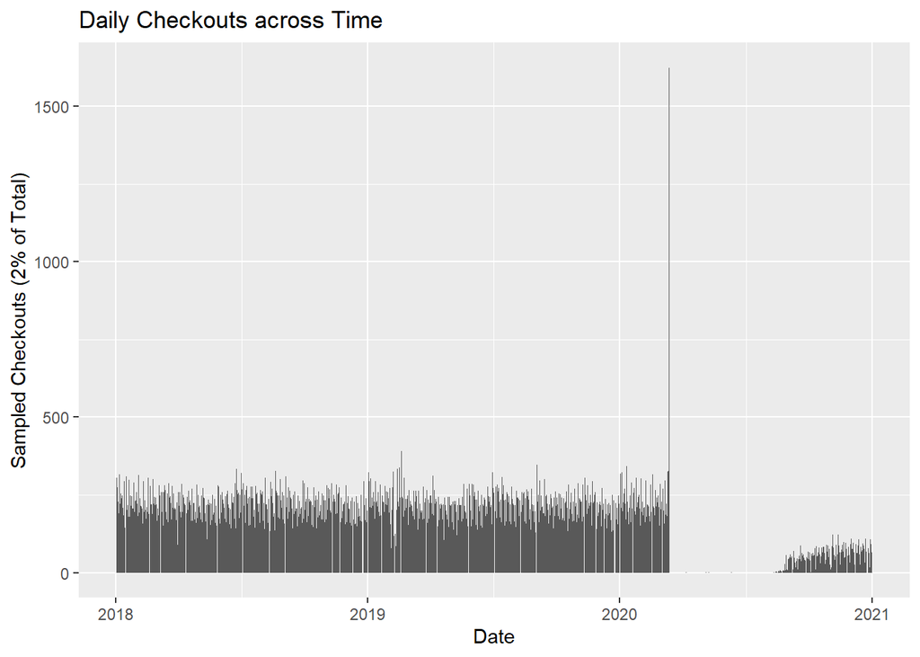

```r
# by day
df.byday <- checkouts %>%
  group_by(Date) %>%
  summarize(DailyCheckouts = n())
(ggplot(df.byday)
  + aes(x = Date, y = DailyCheckouts)
  + geom_histogram(stat = "identity") # because I already aggregated above
  + ggtitle("Daily Checkouts across Time")
  + scale_x_date("Date")
  + scale_y_continuous("Sampled Checkouts (2% of Total)")
  )
```

```r
# one crazy outlier! Let's look at it.
df.byday %>%
  filter(DailyCheckouts == max(df.byday$DailyCheckouts))
```

```
## # A tibble: 1 x 2
##   Date       DailyCheckouts
##   <date>              <int>
## 1 2020-03-13           1625
```

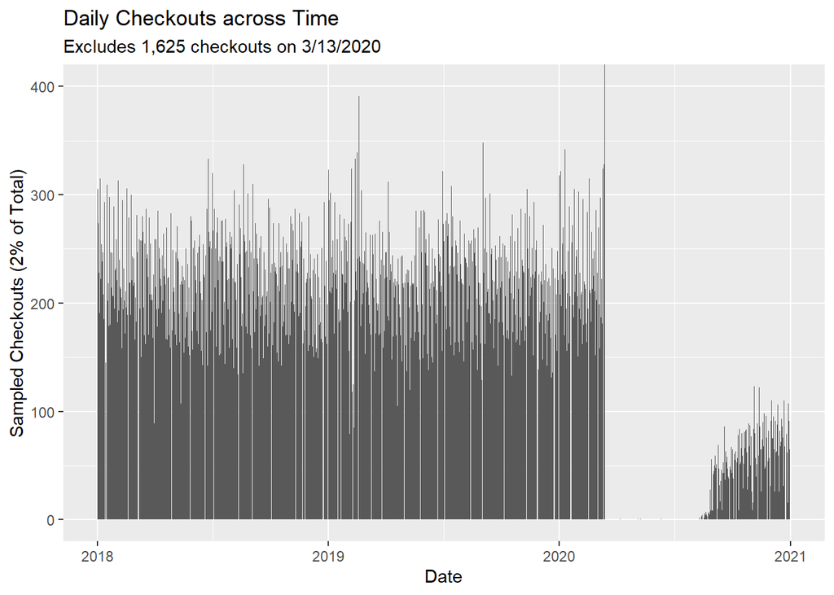

```r
# 3/13/2020 - the day before the library closes for lockdown

# repeat plot above but zooming in to exclude 3/13/2020 value...
(ggplot(df.byday)
  + aes(x = Date, y = DailyCheckouts)
  + geom_histogram(stat = "identity") # because I already aggregated above
  + ggtitle("Daily Checkouts across Time",
            subtitle = "Excludes 1,625 checkouts on 3/13/2020")
  + scale_x_date("Date")
  + scale_y_continuous("Sampled Checkouts (2% of Total)")
  + coord_cartesian(ylim = c(0,400))
  )
```

```r
ggsave(filename = paste0(GRAPHDIR,"week1_dailycheckouts_zoomed.png"),
       width = PLOT_WIDTH*1.4, # add multipliers to make image a little bigger or smaller as needed (if needed)
       height = PLOT_HEIGHT,
       units = PLOT_UNITS)
```

```r
# What do the HOURLY checkouts look like for that one day?
day20200313 <- checkouts %>% filter(Date == as.Date("2020-03-13"))

png(filename = paste0(GRAPHDIR,"week1_hourlycheckouts_20200313.png"),
    width = PLOT_WIDTH,
    height = PLOT_HEIGHT,
    units = PLOT_UNITS,
    res = PLOT_RES)

hist(x = as.numeric(day20200313$Hour),
     breaks = rep(min(day20200313$Hour):max(day20200313$Hour), each=2) +
                c(-0.4, 0.4),
     freq = FALSE,
     main = "Hourly checkouts for 3/13/2020",
     ylab = "Fraction of Checkouts",
     xlab = "Hour of 3/13/2020",
     col = "light blue"
     )

dev.off()
```

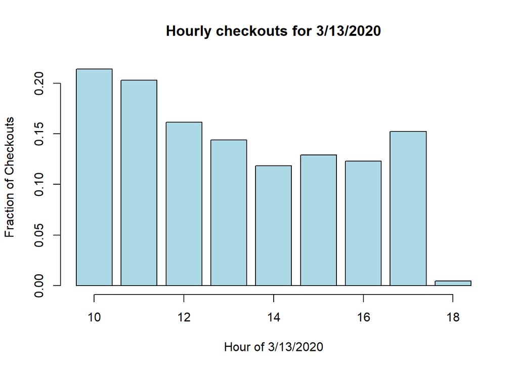

```r
# repeating hist() so that it displays in the Knitted R...
hist(x = as.numeric(day20200313$Hour),
     breaks = rep(min(day20200313$Hour):max(day20200313$Hour), each=2) +
                c(-0.4, 0.4),
     freq = FALSE,
     main = "Hourly checkouts for 3/13/2020",
     ylab = "Fraction of Checkouts",
     xlab = "Hour of 3/13/2020",
     col = "light blue"
     )
```

```r
# What I'm doing with breaks in the hist() above.
#   Setting default breaks such that each integer value falls in the middle.
#   Adapted from Jonathan Christensen's answer: https://stackoverflow.com/questions/14392647/how-to-separate-the-two-leftmost-bins-of-a-histogram-in-r
#      1) determine range via min/max calls
#      2) create a set of pairs of identical numbers in that range
rep(min(day20200313$Hour):max(day20200313$Hour), each=2)
```

```
##  [1] 10 10 11 11 12 12 13 13 14 14 15 15 16 16 17 17 18 18
```

```r
#      3) now let's subtract a little from the first of the pair, and add a little to the second of the pair; we are benefitting from R's tendency to repreat a list over and over. Change the values to shift the widths
rep(min(day20200313$Hour):max(day20200313$Hour), each=2) + c(-0.4, 0.4)
```

```
##  [1]  9.6 10.4 10.6 11.4 11.6 12.4 12.6 13.4 13.6 14.4 14.6 15.4 15.6 16.4 16.6
## [16] 17.4 17.6 18.4
```

*Exclude 3/13/2020 data as an extreme outlier*

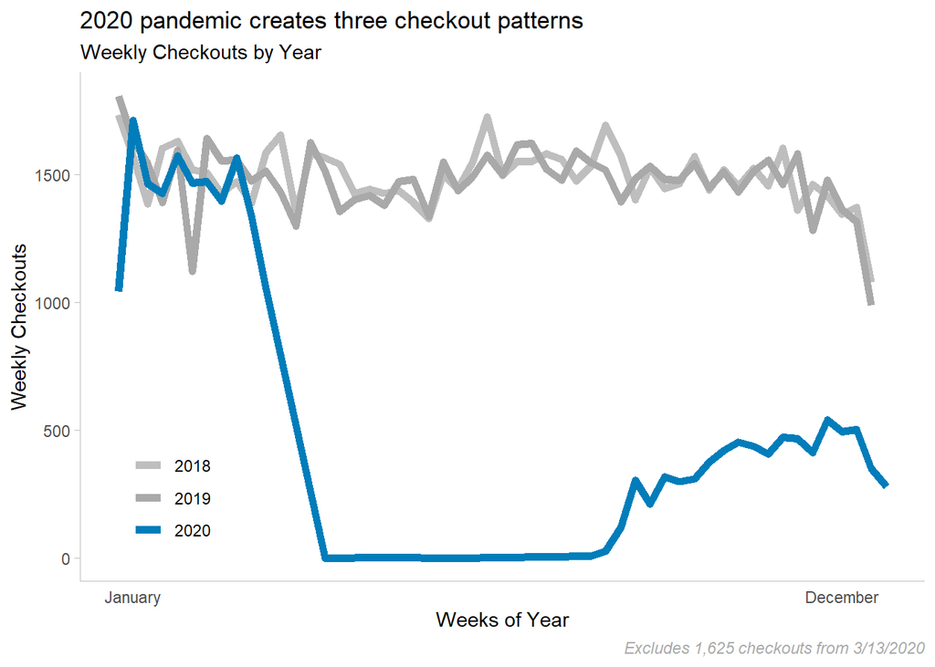

```r
# getting a bit fancy with the ggplot themes :-)
df.byweek <- checkouts %>%
             filter(Date != as.Date("2020-03-13")) %>%
             group_by(Year, WeekOfYear) %>%
             summarize(WeeklyCheckouts = n())
(ggplot(df.byweek)
  + aes(x = as.numeric(WeekOfYear), y = WeeklyCheckouts, color = factor(Year))
  + geom_line(size = 2)
  + scale_x_continuous("Weeks of Year",
                       breaks = c(2, 50), # just approximates
                       labels = c("January", "December"))
  + scale_y_continuous("Weekly Checkouts")
  + ggtitle("2020 pandemic creates three checkout patterns",
            subtitle = "Weekly Checkouts by Year")
  + labs(caption = "Excludes 1,625 checkouts from 3/13/2020")
  + scale_color_manual(name = "",
                       labels = c("2018", "2019", "2020"),
                       values = c("grey", "dark grey", "#007DBA")) # cerulean?
  + theme_minimal()
  + theme(
      # update some theme items
      panel.grid.major = element_blank(),
      panel.grid.minor = element_blank(),
      axis.ticks.y = element_line(size = 0.1, color = "grey"),
      axis.line = element_line(size = 0.1, color = "grey"),

      # legend updates
      legend.position = c(0.05, 0.05),
      legend.justification = c("left", "bottom"),
      legend.background = element_blank(),

      # plot caption updates
      plot.caption = element_text(color = "dark grey",
                                  face = "italic")
  )
  )
```

```r
ggsave(filename = paste0(GRAPHDIR,"weeklyCheckouts.png"),
       width = PLOT_WIDTH*1.2, # add multipliers to make image a little bigger or smaller as needed (if needed)
       height = PLOT_HEIGHT,
       units = PLOT_UNITS)
```

```r
# first get the summary across the two categorical fields
freqCategoryAge <- checkouts %>%
                   group_by(Age,
                            # combine collection/subcollection on the fly:
                            Collection = paste0(Collection, ":", SubCollection)) %>%
                   summarize(Count = n())
# now make this LONG table WIDE with pivot_wider() from tidyr
prettyCategoryAge <- freqCategoryAge %>%
                     # Set Age as column names in wide form, fits better with Cat/SubCat as row names
                     pivot_wider(names_from = Age,
                                 values_from = Count,
                                 values_fill = 0) # default value if missing
prettyCategoryAge
```

```
## # A tibble: 10 x 3
##    Collection             Adult Juvenile
##    <chr>                  <int>    <int>
##  1 Fiction:Comic           5923    10159
##  2 Fiction:General        33177    21765
##  3 Fiction:Holiday           17     1881
##  4 Fiction:Large Print     2084       31
##  5 Fiction:Peak Picks      4916        0
##  6 Fiction:Picture            8    34645
##  7 Nonfiction:Biography    1626      682
##  8 Nonfiction:General     44008    13121
##  9 Nonfiction:Large Print   460        0
## 10 Nonfiction:Peak Picks   4438        0
```

```r
# convert to percentages by Age
percentAgeByCategory <- prettyCategoryAge
percentAgeByCategory$Adult <- paste(round(percentAgeByCategory$Adult /
                                            sum(percentAgeByCategory$Adult) * 100, 2),
                                    "%")
percentAgeByCategory$Juvenile <- paste(round(percentAgeByCategory$Juvenile /
                                               sum(percentAgeByCategory$Juvenile) * 100, 2),
                                       "%")
percentAgeByCategory
```

```
## # A tibble: 10 x 3
##    Collection             Adult   Juvenile
##    <chr>                  <chr>   <chr>
##  1 Fiction:Comic          6.13 %  12.35 %
##  2 Fiction:General        34.32 % 26.45 %
##  3 Fiction:Holiday        0.02 %  2.29 %
##  4 Fiction:Large Print    2.16 %  0.04 %
##  5 Fiction:Peak Picks     5.09 %  0 %
##  6 Fiction:Picture        0.01 %  42.1 %
##  7 Nonfiction:Biography   1.68 %  0.83 %
##  8 Nonfiction:General     45.53 % 15.95 %
##  9 Nonfiction:Large Print 0.48 %  0 %
## 10 Nonfiction:Peak Picks  4.59 %  0 %
```

```r
# export table
write.csv(percentAgeByCategory,
          file = paste0(TABLEDIR, "week1_percentAgebyCollection.csv"),
          row.names = FALSE)
# We will apply final formatting in our Report...
```

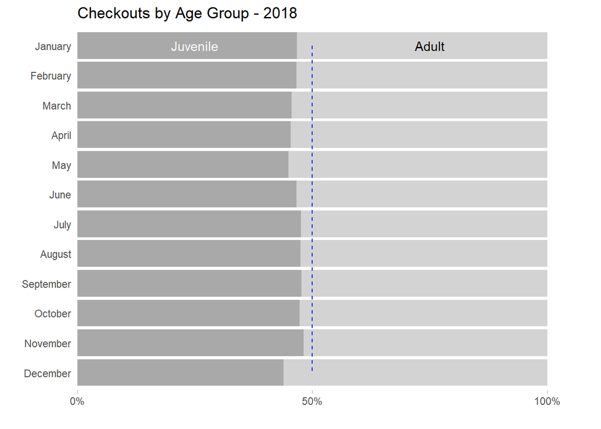

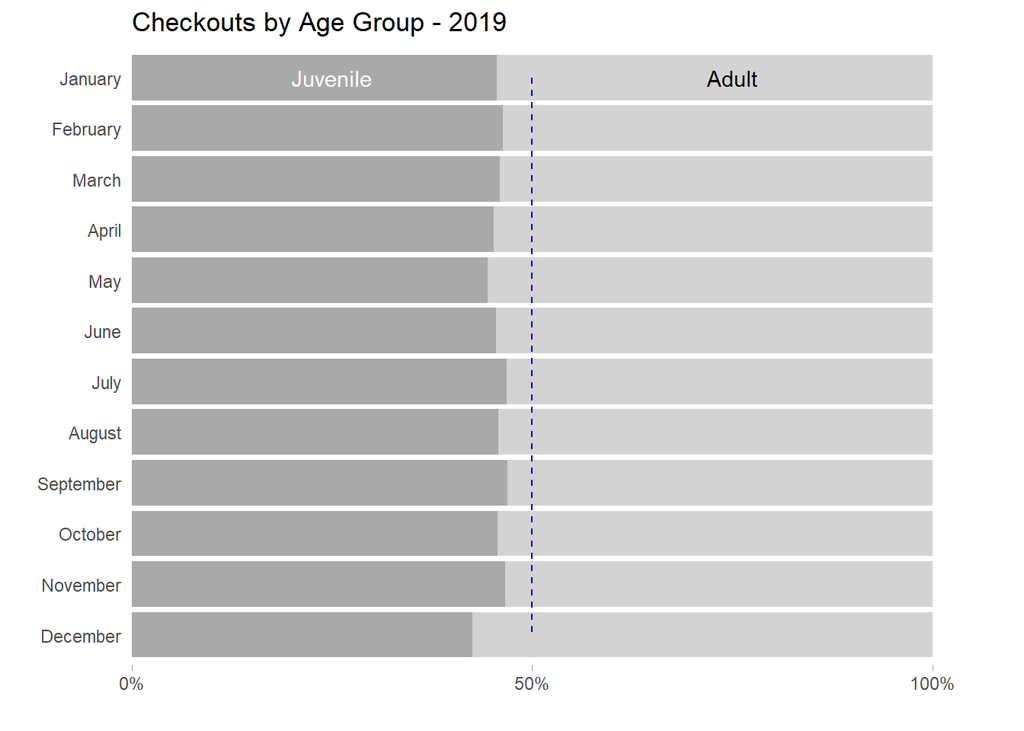

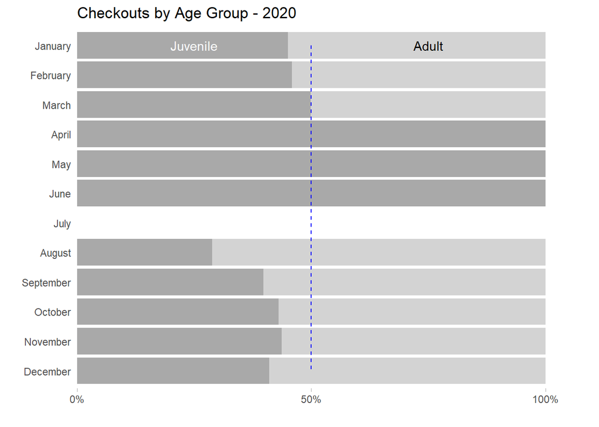

```r
# Want: stacked bar graph showing fraction Adult vs Juvenille Checkouts by Month
# One graph per year (loop over years)

df.byAgeMonthYear <- checkouts %>%
                     group_by(Year, Month, Age) %>%
                     summarize(MonthlyCount = n())
for (year in c(2018, 2019, 2020)) {
  # have to explicitly PRINT() ggplot if within for loop
  print(ggplot(df.byAgeMonthYear[df.byAgeMonthYear$Year == year, ]) # slice our data to just the year of interest
   + aes(x = Month, y = MonthlyCount, fill = Age)
   + geom_bar(stat = "identity", # we already did the math
              position = "fill") # to get 100% stacks; use position = "stack" for variable heights
   + coord_flip()
   + scale_fill_manual(breaks = c("Adult", "Juvenile"),
                       values = c("light grey", "dark grey"))
   + scale_x_discrete("",
                      # reverse order of the labels
                      limits = rev(levels(df.byAgeMonthYear$Month)))
   + scale_y_continuous("",
                        breaks = c(0, 0.5, 1),
                        labels = c("0%", "50%", "100%"),
                        expand = expansion(mult = c(0, 0.1)))
   # update title for each year
   + ggtitle(paste0("Checkouts by Age Group - ", year))

   # add annotations for Juvenile and Adult (instead of legend)
   + annotate("text", label = "Juvenile",
              x = "January", y = 0.25,
              color = "white")
   + annotate("text", label = "Adult",
              x = "January", y = 0.75,
              color = "black")

   # add annotation for 50% mark
   + annotate("segment",
              x = "January", xend = "December",
              y = 0.5, yend = 0.5,
              color = "blue", linetype = "dashed")

   # aesthetic changes
   + theme_minimal()
   + theme(
        legend.position = "none",

        # details with background...
        panel.grid.major = element_blank(),
        panel.grid.minor = element_blank(),
        axis.ticks.x = element_line(size = 0.1, color = "dark grey")
   )
   )



  ggsave(filename = paste0(GRAPHDIR,"week1_checkoutsByAge_", year, ".png"),
       width = PLOT_WIDTH * 1.2, # add multipliers to make image a little bigger or smaller as needed (if needed)
       height = PLOT_HEIGHT,
       units = PLOT_UNITS)
}
```

```r
df.byAgeMonthYear[df.byAgeMonthYear$Year == 2020, ] %>%
  pivot_wider(names_from = Age,
              values_from = MonthlyCount,
              values_fill = 0)
```

```
## # A tibble: 11 x 4
## # Groups:   Year, Month [11]
##     Year Month     Adult Juvenile
##    <int> <ord>     <int>    <int>
##  1  2020 January    3695     3033
##  2  2020 February   3358     2844
##  3  2020 March      2116     2106
##  4  2020 April         0        1
##  5  2020 May           0        2
##  6  2020 June          0        1
##  7  2020 August      116       47
##  8  2020 September   773      511
##  9  2020 October    1031      779
## 10  2020 November   1024      796
## 11  2020 December   1261      877
```

## Week 2

### Assignment (summarized)

1. Produce several descriptive statistics tables (mean, SD, min, max, N) for entire sample & by group
2. Create jitterplot, scatterplot, and boxplot; export these to png

### Step 0 - Data preparation - Weekly Counts

Assumes that we have run at least these prior chunks:

- Project Setup
- Load Data
- Data Cleanup

All resulting in a cleaned checkouts data.frame

```r
head(checkouts)
```

```
##         Date Year WeekOfYear     Month DayOfWeek Hour   Age Collection
## 1 2019-05-30 2019         22       May  Thursday   14 Adult Nonfiction
## 2 2018-12-23 2018         51  December    Sunday   14 Adult Nonfiction
## 3 2019-10-02 2019         40   October Wednesday   16 Adult Nonfiction
## 4 2019-10-11 2019         41   October    Friday   17 Adult Nonfiction
## 5 2018-11-03 2018         44  November  Saturday   10 Adult Nonfiction
## 6 2018-09-09 2018         36 September    Sunday   13 Adult Nonfiction
##   SubCollection
## 1     Biography
## 2     Biography
## 3     Biography
## 4     Biography
## 5     Biography
## 6     Biography
```

```r
df.byWeek <- checkouts %>%
             group_by(Year, WeekOfYear) %>%
             summarize(weeklyCount = n())
```

### Step 1 - Produce descriptive statistics tables

```r
# let's build the overall one by hand
overallStats <- data.frame("Group" = "Overall",
                           "Mean" = mean(df.byWeek$weeklyCount),
                           "Median" = median(df.byWeek$weeklyCount),
                           "Std.Dev" = sd(df.byWeek$weeklyCount),
                           "Min" = min(df.byWeek$weeklyCount),
                           "Max" = max(df.byWeek$weeklyCount),
                           "N" = length(df.byWeek$weeklyCount))
overallStats
```

```
##     Group     Mean Median  Std.Dev Min  Max   N
## 1 Overall 1287.345   1466 483.1753   1 2680 139
```

```r
# let's use dplyr's group_by/summarize to build the rest
statsByYear <- df.byWeek %>%
  group_by("Group" = Year) %>% # changing the name to match our overallStats table
  summarize("Mean" = mean(weeklyCount),
            "Median" = median(weeklyCount),
            "Std.Dev" = sd(weeklyCount),
            "Min" = min(weeklyCount),
            "Max" = max(weeklyCount),
            "N" = n()) # here we are counting the rows in the Year

statsByYear
```

```
## # A tibble: 3 x 7
##   Group  Mean Median Std.Dev   Min   Max     N
##   <int> <dbl>  <dbl>   <dbl> <int> <int> <int>
## 1  2018 1494.  1501     112.  1079  1734    52
## 2  2019 1478.  1488.    130.   990  1809    52
## 3  2020  696.   437     650.     1  2680    35
```

```r
# we can row-bind our two tables since we have been careful to keep the same column order
summaryStats <- rbind(overallStats,
                      statsByYear)
summaryStats
```

```
##     Group      Mean Median  Std.Dev  Min  Max   N
## 1 Overall 1287.3453 1466.0 483.1753    1 2680 139
## 2    2018 1494.0769 1501.0 112.0903 1079 1734  52
## 3    2019 1478.4231 1488.5 130.4779  990 1809  52
## 4    2020  696.3143  437.0 649.9136    1 2680  35
```

```r
# Finally let's use Age as a grouping...
# we need to repeat our original byWeek grouping but to include Age
df.byAgeWeek <- checkouts %>%
  group_by(Year, WeekOfYear, Age) %>%
  summarize(weeklyCount = n())
head(df.byAgeWeek)
```

```
## # A tibble: 6 x 4
## # Groups:   Year, WeekOfYear [3]
##    Year WeekOfYear Age      weeklyCount
##   <int> <chr>      <chr>          <int>
## 1  2018 01         Adult            926
## 2  2018 01         Juvenile         808
## 3  2018 02         Adult            851
## 4  2018 02         Juvenile         719
## 5  2018 03         Adult            713
## 6  2018 03         Juvenile         673
```

```r
# let's repeat our group_by version to use the df.byAgeWeek data
statsByAge <- df.byAgeWeek %>%
  group_by("Group" = Age) %>% # changing the name to match our overallStats table
  summarize("Mean" = mean(weeklyCount),
            "Median" = median(weeklyCount),
            "Std.Dev" = sd(weeklyCount),
            "Min" = min(weeklyCount),
            "Max" = max(weeklyCount),
            "N" = n()) # here we are counting the rows in the Year
statsByAge
```

```
## # A tibble: 2 x 7
##   Group     Mean Median Std.Dev   Min   Max     N
##   <chr>    <dbl>  <dbl>   <dbl> <int> <int> <int>
## 1 Adult     711.   786.    233.     7  1288   136
## 2 Juvenile  592.   675     235.     1  1392   139
```

```r
# rbind to the same ongoing table
summaryStats <- rbind(summaryStats,
                      statsByAge)

# now let's export
write.csv(summaryStats,
          file = paste0(TABLEDIR, "week2_summarystats.csv"),
          row.names = FALSE)
```